# Review of Statistical Concepts

Yanchao Liu

8/26/2018

The material below is based on the book *Multiple Regression and Analysis of Variance* by George O. Wesolowsky.

### Random Variables

A **random variable** is a function or rule that assigns a number to each possible outcome of an experiment or sample. For example, when a coin is tossed three times, the number of heads that occurs can be considered a random variable. This random variable can take the values 0, 1, 2 and 3.

A **discrete random variable** can take only isolated values; a **continuous random variable** can take any value within a range of values, e.g., the height of an adult male chosen from the U.S. population can take any value within the range of heights for adult males.

### Probability Distributions

When a measure of probability is assigned to each possible outcome for a random variable $X$, a **probability distribution** is produced. A **discrete probability distribution** is simply a list of probabilities, one of which is assigned to each possible value of a random variable. The sum of the probabilities must always equal to 1.

**Example:** If $X$ is the total number of heads in three tosses of a coin, the probability distribution for $X$ can be given by the table

| X | 0 | 1 | 2 | 3 |
| --- | --- | --- | --- | --- |
| Pr(X) | 1/8 | 3/8 | 3/8 | 1/8 |

or by the function
$$Pr(X) = \frac{3!}{X!(3-X)!} \cdot (\frac{1}{2})^X \cdot (\frac{1}{2})^{(3-X)}$$
$X$ follows a binomial distribution, and the above function is its **probability mass function**. $\blacksquare$

The probabilty distribution of a continuous random variable is given by the **probability density function**. If the probability density function is plotted against $X$, the area under its curve (bounded by the X axis) is equal to 1. Furthermore, the area under the curve between any $X$ values $X=a$ and $X=b$ is equal to the probability that $X$ will lie between $a$ and $b$.

### Expected Values

For a discrete random variable $X$ the *expected value* $E(X)$ is given by
$$E(X) = \sum_{i=1}^n X_i Pr(X_i)$$
where the subscript $i$ serves to identify each of the $n$ possible values of $X$.

The expected value of a continuous random variable is
$$E(X) = \int_{r_1}^{r_2} X f(X) dX$$
where the range of $X$ is $r_1$ to $r_2$ and $f(X)$ is the probability density function of $X$.

The expected value of a variable can be thought of loosely as the long-run average of that variable.

**Example:** What is the long-run average number of heads we expect when we keep repeating the experiment of tossing a coin three times?
$$E(X) = 0 (\frac{1}{8}) + 1 (\frac{3}{8}) + 2 (\frac{3}{8}) + 3 (\frac{1}{8}) = 1.5$$
$\blacksquare$

The following rules are useful in operating with expected values:

1. $E(C) = C$. The expected value of a constant C is the constant itself.
2. $E(C \cdot X) = C \cdot E(X)$. The expected value of a constant times a variable is the constant times the expected value of the variable.
3. $E(X \pm Y) = E(X) \pm E(Y)$. The expected value of the sum (or difference) of two variables is the sum (or difference) of the expected values of those variables.

### Variance

The **variance** of random variable, whether discrete or continuous, is the expected value of the squared deviation of the variable from the expected value of that variable:
$$\text{VAR}(X) = E((X-E(X))^2)$$
**Example:** If $X$ is the number of heads obtained in tossing a coin three times, $E(X) = 1.5$ and $\text{VAR}(X)$ is
$$(0-1.5)^2 (\frac{1}{8}) + (1-1.5)^2 (\frac{3}{8}) + (2-1.5)^2 (\frac{3}{8}) + (3-1.5)^2 (\frac{1}{8}) = 0.75$$
$\blacksquare$

Useful rules for working with variances:

1. $\text{VAR}(X+C) = \text{VAR}(X)$. The variance of a random variable plus a constant is equal to the variance of that random variable.
2. $\text{VAR}(XC) = C^2 \text{VAR}(X)$. The variance of random variable multiplied by a constant is equal to the constant squared times the variance of the random variable.
3. $\text{VAR}(X+Y) = \text{VAR}(X) + \text{VAR}(Y) + 2E((X-E(X))(Y-E(Y)))$. The variance of the sum of two random variables $X$ and $Y$ is equal to the sum of the variances of $X$ and $Y$ plus twice $E((X-E(X))(Y-E(Y)))$, a quantity called the **covariance** of $X$ and $Y$.

The expected value (also called the **mean**) of a random variable depicts the “center” of its probability distribution on the X axis, where as the variance depicts the dispersion, or spread, of the probability distribution on the X axis.

We also use the term variance to measure the dispersion of a population of $N$ values or observations:
$$\text{VAR}(X) = \frac{\sum_{i=1}^{N} (X_i - \mu_X)^2}{N}$$
where $X_i = 1, \ldots, N$ are observations and $\mu_X = \sum_{i=1}^N X_i/N$ is the average value in the population.

The **standard deviation** is the positive square root of variance and is written as $\text{SD}(X)$.

### The Normal Distribution

A continuous random variable $X$, with a possible range of $-\infty$ to $+\infty$ and with an expected value $\mu_X$ and standard deviation $\sigma_X$ has a **normal probability distribution** if its probability density function is given by
$$f(X) = \frac{1}{\sqrt{2 \pi} \sigma_X} exp[-\frac{1}{2}(\frac{X-\mu_X}{\sigma_X})^2]$$

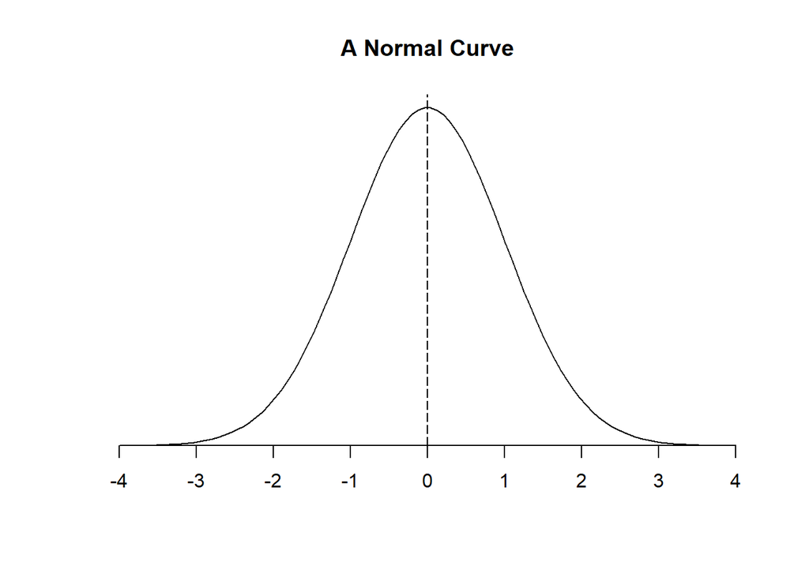

See [probability plots](http://www.statmethods.net/advgraphs/probability.html).

Consider a normal random variable $X$ with an expected value $\mu_X$ and standard deviation $\sigma_X$. Define a new random variable $z$ by
$$z = \frac{X - \mu_X}{\sigma_X}$$
Because $\mu_x$ and $\sigma_X$ are constants, $z$ also has a normal distribution.
$$E(z) = E(\frac{X-\mu_x}{\sigma_X}) = \frac{1}{\sigma_X}(E(X) - \mu_X) = \frac{1}{\sigma_X}(\mu_X - \mu_X) = 0$$
$$\text{VAR}(z) = E((\frac{X-\mu_X}{\sigma_X} - E(z))^2) = E((\frac{X-\mu_X}{\sigma_X})^2) = \frac{1}{\sigma_X^2} E((X-\mu_X)^2) = \frac{\sigma_X^2}{\sigma_X^2} = 1$$
The random variable $z$ has mean 0 and standard deviation 1 and is said to have a **standard normal distribution**. Probability tables for $z$ is readily available and can be used to find probabilities for any normally distributed random variables.

**Example:** Find $\text{Pr}(40 \le X \le 70)$ if $X$ is normally distributed with mean 50 and standard deviation 20.

$z_1 = (40-50)/20 = -0.5$, $z_2 = (70-50)/20 = 1$. From the Normal Table (which gives the area under the standard normal curve to the left of any z), we find that $\text{Pr}(z \le 1) = 0.8413$ and $\text{Pr}(z \le -0.5) = 0.3085$, so $\text{Pr}(40 \le X \le 70) = \text{Pr}(-0.5 \le z \le 1) = 0.8413 - 0.3085 = 0.5328$. This is illustrated in the figure below.

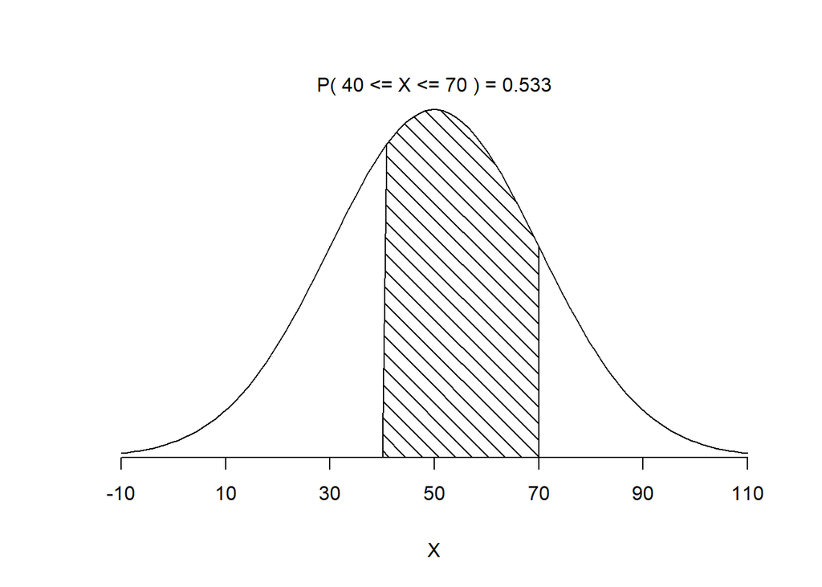

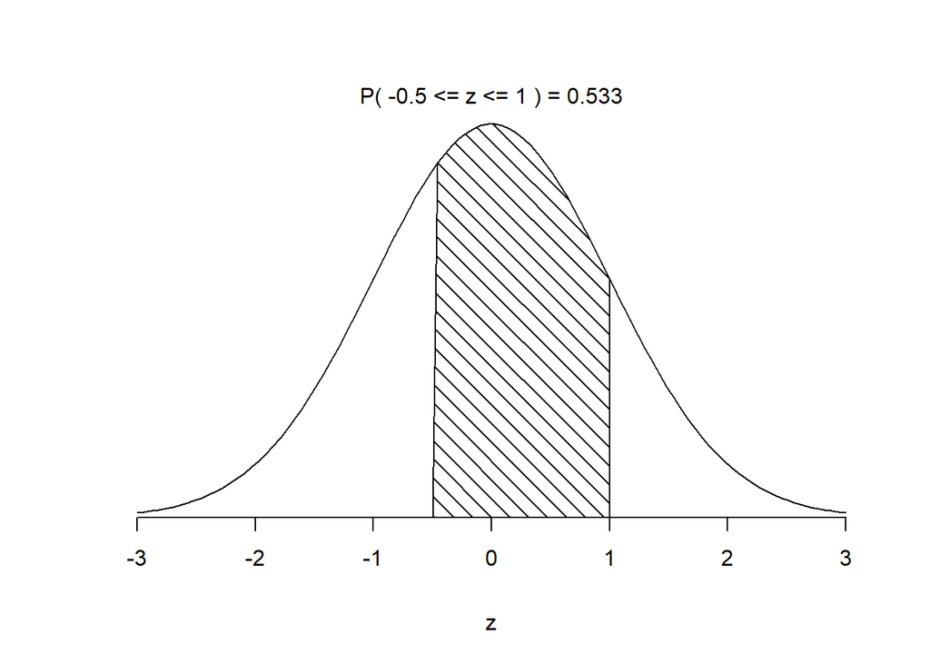

### Sampling Distribution of the Mean

A **statistic** is a random variable whose value is calculated from sample data. It is a random variable because the same calculation for different samples from the same population may produce different values. For example, $\bar{X} = \sum_{i=1}^{n} X_i/n$, called the **sample mean**, is a statistic. It is the average of $n$ values, namely $X_1, \ldots, X_n$, chosen from a population in a manner that gives each value the same chance of being chosen. The statistic $\bar{X}$ is often used in estimating a population mean or in testing hypotheses concerning a population mean. Technically, a single value $X$ randomly chosen from a population is itself a statistic.

A statistic, being a random variable, will have a probability distribution, which is called the **sampling distribution**; its standard deviation is the **standard error** of the statistic.

The distribution of $\bar{X}$ is described by two theorems: one gives the expected value and the variance, and the other gives the shape.

**Theorem:** Let $X_1,\ldots,X_n$ be a random sample from a population with mean $\mu_X$ and variance $\sigma_X^2$, then $E(\bar{X}) = \mu_X$ and $\text{VAR}(\bar{X}) := \sigma_{\bar{X}}^2 = \sigma_X^2/n$.

**Central Limit Theorem:** If an infinitely large population has a mean $\mu_X$ and standard deviation $\sigma_X$, the distribution of the sample mean $\bar{X}$ approaches the normal distribution with mean $\mu_X$ and standard deviation $\sigma_\bar{X} = \sigma_X/\sqrt{n}$ as the sample size $n$ increases.

The distribution of $t$ will be “flatter” or more dispersed than the distribution of $z$. This is because the presence of another random variable $S_X$ gives more variability to the statistic. The amount of this additional variability is a function of $n$. As the sample size increases, the estimate $S_X$ becomes stable. When $n$ is small, there is a noticeably different distribution of $t$ for every $n$. When $n$ is greater than 30, however, $S_X$ is sufficiently close to $\sigma_X$ and $z$ and $t$ are nearly identical. Tables for the distribution of $t$ are in terms of $\nu = n - 1$, called the **degree of freedom**.

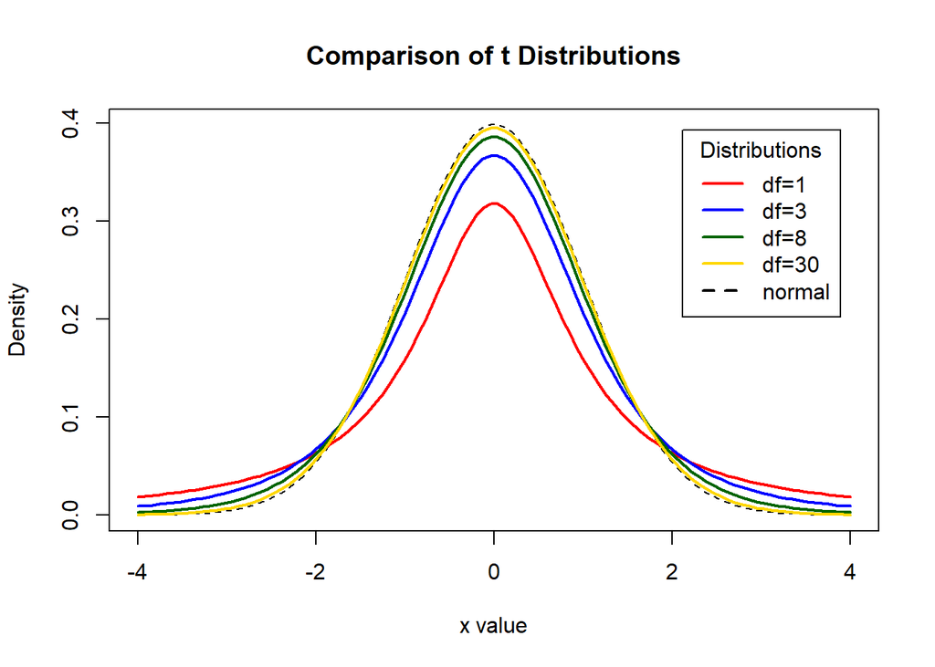

### Estimation

Statistics, i.e., random variables whose values are calculated from sample data, are primarily used for (1) the estimation of the population **parameters** such as the population mean or variance, and (2) the testing of hypotheses about parameters.

We judge the quality of statistics as estimators by these criteria:

- Bias
- Mean Squared Error
- Consistency
- Maximum Likelihood

#### Bias

An estimator $\hat{\theta}$ is said to be an unbiased estimator for a parameter $\theta$ if $E(\hat{\theta}) = \theta$, that is, if the “long-run” average of the random variable $\hat{\theta}$ is $\theta$, the value of the parameter. For example, $\bar{X}$ is an unbiased estimator of $\mu_X$, the population mean, because $E(\bar{X}) = \mu_X$. Also, $S_X^2$ is an unbiased estimator of $\sigma_X^2$, the population variance.

Lack of bias is a desirable, but not necessarily indispensible, property of an estimator.

#### Mean Squared Error

The mean squared error of an estimator $\hat{\theta}$ is $E(\hat{\theta} - \theta)^2$, or the expected value of its squared deviation from the parameter $\theta$. For unbiased estimators the mean squared error is obviously equal to the variance of the estimator. A unbiased estimator with a smaller variance than antoher unbiased estimator is said to be **relatively more efficient**.

#### Consistency

An estimator is said to be **consistent** if values of $\hat{\theta}$ can be made to converge to $\theta$ by increasing the sample size $n$. For example, $(\bar{X} + 1/n^2)$ is a consistent estimator of $\mu_X$ because $(\bar{X} + 1/n^2) \rightarrow \mu_X$ as $n \rightarrow \infty$. However, $(\bar{X} + 1/n^2)$ is a biased estimator for $\mu_X$ because $E(\bar{X} + 1/n^2) = \mu_X + 1/n^2 \neq \mu_X$.

An unbiased estimator may or may not be consistent. In general, consistency is a desirable property because it gives us hope that larger samples will give better estimates.

#### Maximum Likelihood

Given a particular set of sample observations, we choose as our estimator of $\theta$ the estimator $\hat{\theta}$ that maximizes the probability (or probability density) of obtaining those observations. It turns out that $\bar{X}$ is a maximum likelihood estimator for $\mu_X$. However, $S_X^2$ is not a maximum likelihood estimator for $\sigma_X^2$ (but $(n-1)S_X^2/n$ is). The maximum likelihood principle is a good method for searching for estimators.